# Comparaison du MIC de plusieurs matrices de spectres

Patrick Guerin

avril 15, 2018,17:28

Afin de vérifier si le traitement Peps automatisé est correct, on compare celui-ci à un traitement manuel sur la abse de l’indice MIC (Metabolomic information content)

# 1 Lecture des matrices des spectres et initiatilisation des variables utiles

```r
#  Choix du répertoire où sont les matrices de donnÃ©es
pathdir="~/Traitement des données omics/Devoirs/P6  Prétraitement de données métabolomiques H-NMR/"
#  Definition des matrices à lire dans ce répertoire
data_used=c("CarreLatin_full_Peps.csv","CarreLatinMBXmanualPPMINV.csv")
spectral_matrices_names=c("CarreLatin_full_PEPS","CarreLatin_Manual_500P")
nmatrices=length(data_used)
# Lecture des matrices de données.
## On les stocke dans spectral_matrices_list
## On remplace les noms des colonnes par des noms sans le X
spectral_matrices_list=list()
for(i in 1:nmatrices)
{
spectral_matrices_list[[spectral_matrices_names[i]]]=as.matrix(read.table(file.path(pathdir,data_used[i]),header=T,sep=";",row.names=1,dec="."))
dimnames(spectral_matrices_list[[i]])[[2]]=as.numeric(substring(dimnames(spectral_matrices_list[[i]])[[2]],first=2))
# cat("\n Lecture de la matrice : ",spectral_matrices_names[i])
}



# On recherche la matrice des spectres communs dans les 2 bases (si ce n'est pas le cas au départ), on eleve les blancs des noms
dimnames(spectral_matrices_list[[1]])[[1]]=gsub(" ","",dimnames(spectral_matrices_list[[1]])[[1]]) # on enleve des blancs des noms des spectres.
namespectra=dimnames(spectral_matrices_list[[1]])[[1]]
countspectra=matrix(nrow=nmatrices+1,ncol=2)
dimnames(countspectra)=list(c(spectral_matrices_names,"Common Spectra"),c("Nb of spectra","Nb Buckets"))
countspectra[1,1]=length(namespectra)
countspectra[1,2]=dim(spectral_matrices_list[[1]])[2]
for(i in 2:nmatrices)
{
dimnames(spectral_matrices_list[[i]])[[1]]=gsub(" ","",dimnames(spectral_matrices_list[[i]])[[1]])
newnames=dimnames(spectral_matrices_list[[i]])[[1]]
compnames=is.element(namespectra,newnames)
countspectra[i,1]=length(newnames)
countspectra[i,2]=dim(spectral_matrices_list[[i]])[2]
namespectra=namespectra[compnames]
}
countspectra[nmatrices+1,1]=length(namespectra)
# pander(countspectra)
# On extrait les bons spectres et on les met dans le même ordre
for(i in 1:nmatrices)
{
spectral_matrices_list[[i]]=spectral_matrices_list[[i]][namespectra,]
}
# Creation des variables qui dèfinissent les groupes
TypeY=rep(c("A","B","C"),c(9,9,9))
classY=as.numeric(as.factor(TypeY))
groupes=classY
```

Voilà les spectres d’un example de trois échantillons.

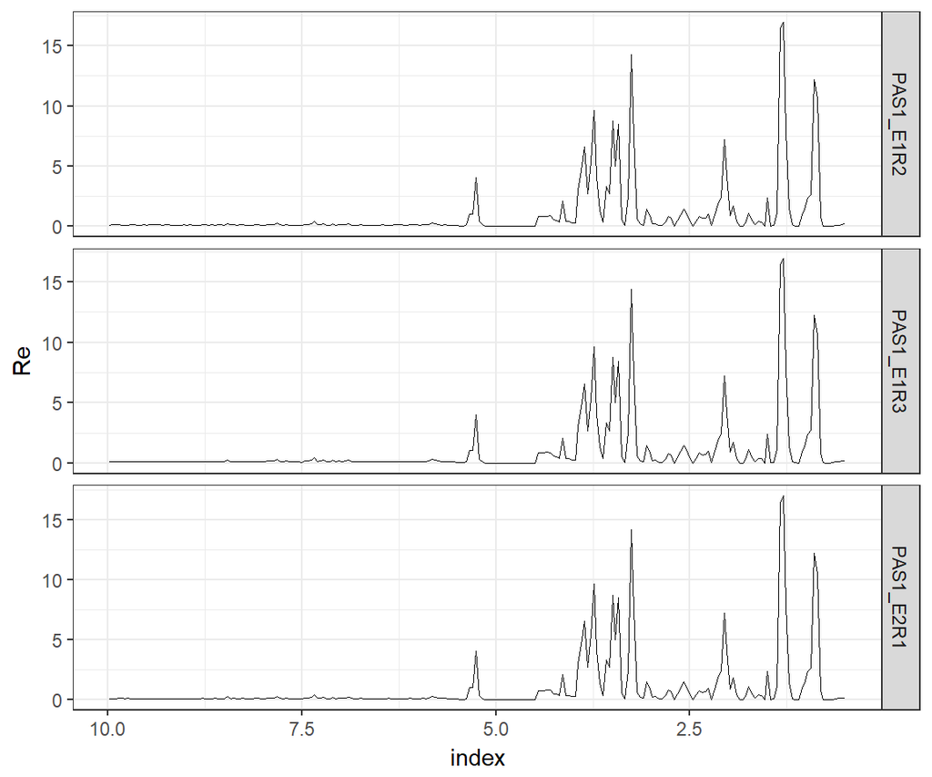

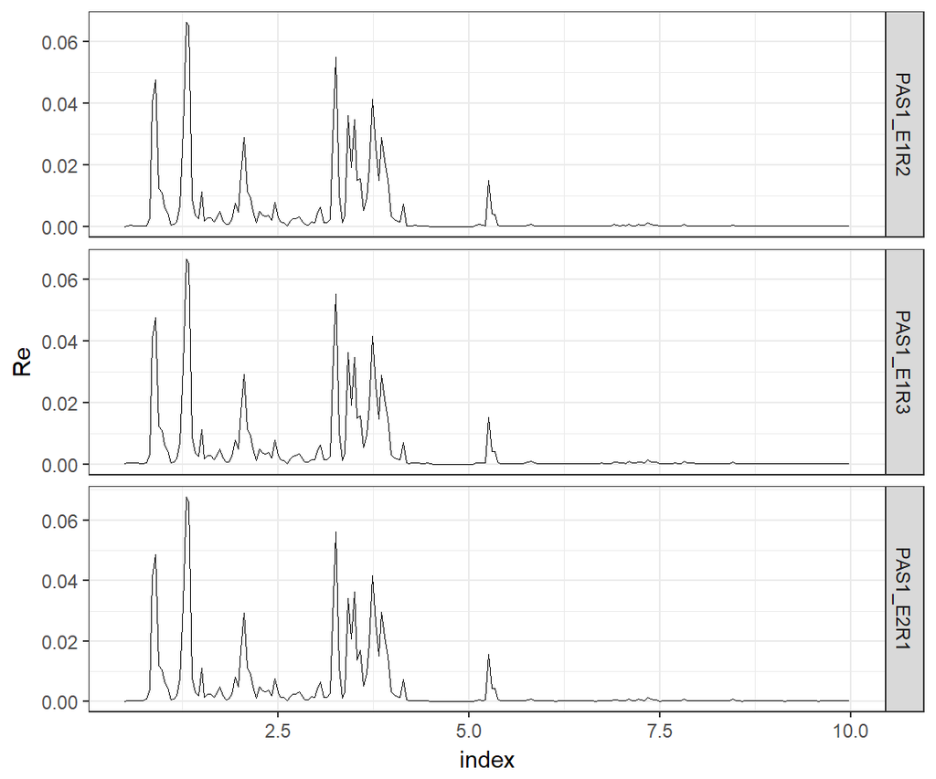

```r
for(i in 1:nmatrices)
{
Draw(spectral_matrices_list[[i]][2:4,],type.draw="signal",subtype="stacked",num.stacked=4)
}
```

# 2 Etude de la répétabilité spectrale

## 2.1 Between and Within group inertia

On commence par comparer les inerties inter et intra-classes de nos deux analyses:

```r
# Impression des résultat des inerties
cat("Inerties non standardisées")
```

```
## Inerties non standardisées
```

```r
pander(list(Inerties_non_standardisees=Inertiavalues,Inerties_en_PC=Inertiapc,Inerties_within_groups=InertiaPerGroup))
```

- **Inerties_non_standardisees**:

  |  | BI | WI | TI |
  | --- | --- | --- | --- |
  | **CarreLatin_full_PEPS** | 516.4 | 143 | 659.4 |
  | **CarreLatin_Manual_500P** | 0.005845 | 0.0005093 | 0.006354 |

- **Inerties_en_PC**:

  |  | BI | WI | TI |
  | --- | --- | --- | --- |
  | **CarreLatin_full_PEPS** | 78.32 | 21.68 | 100 |
  | **CarreLatin_Manual_500P** | 91.99 | 8.015 | 100 |

- **Inerties_within_groups**:

  |  | CarreLatin_full_PEPS | CarreLatin_Manual_500P |
  | --- | --- | --- |
  | **1** | 1.611 | 0.0001048 |
  | **2** | 11.26 | 0.0002399 |
  | **3** | 130.1 | 0.0001645 |
  | **Total** | 143 | 0.0005093 |

On peut constater que l’inertie intra-classes semble plus forte avec le traitement automatisé, ce qui laisse présager une discriminaiton moins bonne qu’avec le traitement manuel des données.

## 2.2 PCA

On réalise ensuite une ACP.

### 2.2.1 Eigenvalues

```r
Eigenvalues=matrix(nrow=nmatrices,ncol=ncompPCA)
dimnames(Eigenvalues)=list(spectral_matrices_names,paste("PC",1:ncompPCA))
for(i in 1:nmatrices)
{
Eigenvalues[i,]=cumsum(PCA.res[[i]][["eigval"]][1:ncompPCA]/sum(PCA.res[[i]][["eigval"]]))
}

pander(Eigenvalues)
```

|  | PC 1 | PC 2 | PC 3 | PC 4 |
| --- | --- | --- | --- | --- |
| **CarreLatin_full_PEPS** | 0.5669 | 0.8237 | 0.9828 | 0.9897 |
| **CarreLatin_Manual_500P** | 0.7612 | 0.9255 | 0.9648 | 0.9807 |

Le traitement manuel semble à nouveau supérieur puisqu’il permet une meilleure explication de la variance sur la abse du premier plan factoriel.

### 2.2.2 PCA Score Plots

```r
draw.scores12 = vector("list")
draw.scores34 = vector("list")
for(i in 1:nmatrices)
{
draw.scores12[[spectral_matrices_names[i]]]=MBXUCL::DrawScores(PCA.res[[i]], drawNames=TRUE, type.obj = "PCA",createWindow=FALSE, main = paste0("PCA score plot for ",spectral_matrices_names[i]),pch = groupes, col = groupes,axes =c(1,2))
draw.scores34[[spectral_matrices_names[i]]]=MBXUCL::DrawScores(PCA.res[[i]], drawNames=TRUE, type.obj = "PCA",createWindow=FALSE, main = paste0("PCA score plot for ",spectral_matrices_names[i]),pch = groupes,col = groupes, axes =c(3,4))
}
```

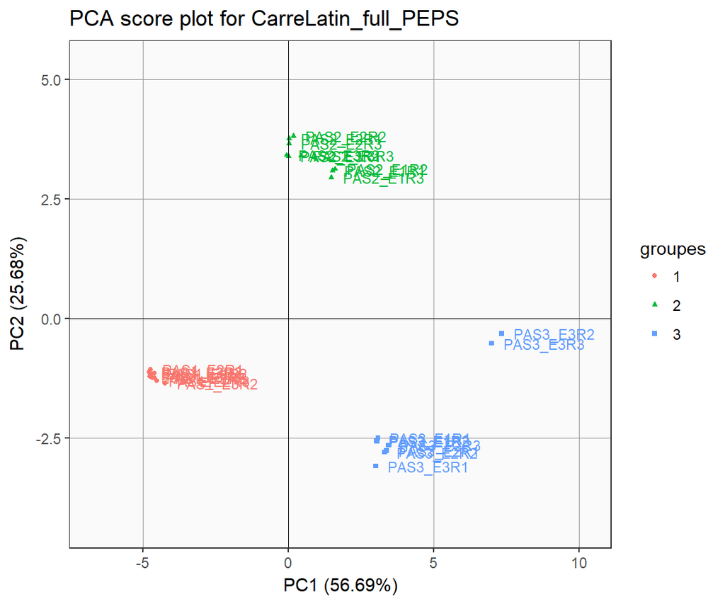

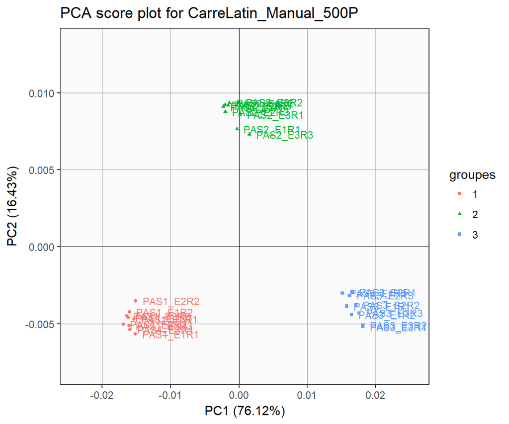

```r
draw.scores12
```

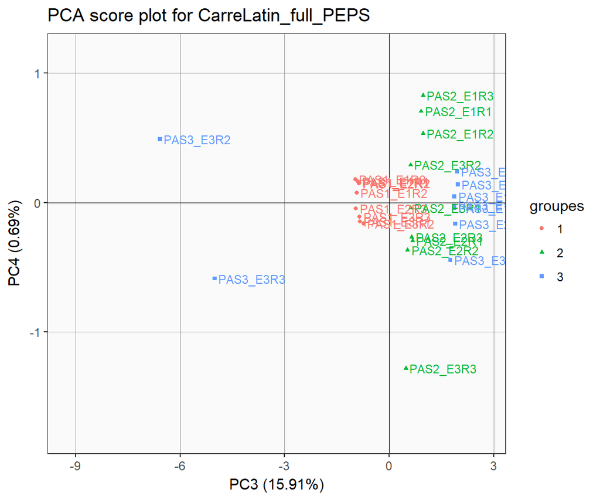

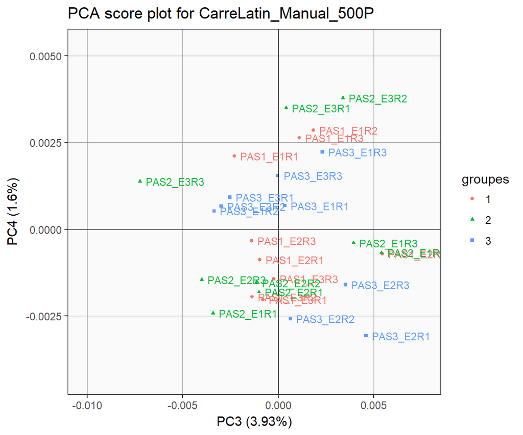

```r
draw.scores34
```

Les plots score confirme cela, on voit bien que que le traitement automatisé classifie moins bien sur les deux premiers axes, avec deux observations relativement éloignés de leur groupe. Cependant les résultats semblent meilleurs que le traitement manuel pour les axes 3 et 4 où les groupes sont mieux discriminés.

```r
draw.loadings12 = vector("list")
draw.loadings34 = vector("list")
for(i in 1:nmatrices)
{
draw.loadings12[[spectral_matrices_names[i]]] = MBXUCL::DrawLoadings(PCA.res[[i]],  type.obj = "PCA",createWindow=FALSE, main = paste0("PCA loadings plot for", spectral_matrices_names[i]),axes = c(1:2), loadingstype="l", num.stacked = 2)[[1]]
draw.loadings34[[spectral_matrices_names[i]]] = MBXUCL::DrawLoadings(PCA.res[[i]],  type.obj = "PCA",createWindow=FALSE, main = paste0("PCA loadings plot for", spectral_matrices_names[i]),axes = c(3:4), loadingstype="l", num.stacked = 2)[[1]]
}
draw.loadings12
draw.loadings34
```

[output not shown]

## 2.3 Unsupervised clustering (MIC)

On peut également réaliser un clustering hiérarchique (distance de ward) afin de vérifier si nos données permettent de regrouper correctement nos échantillons.

```r
nClust = length(unique(groupes)) # nombre de clusters à rechercher
clustres=matrix(0,nrow=nmatrices,ncol=8)
dimnames(clustres)=list(spectral_matrices_names,c("DunnW","DunnKM","DBW","DBKM","RandW","RandKM","AdjRandW","AdjRandKM"))
for(i in 1:nmatrices)
{
print(spectral_matrices_names[i])
ClustMIC.res = MBXUCL::ClustMIC(Intensities = spectral_matrices_list[[i]], nClust = nClust, Trcl = groupes, Dendr = TRUE)
clustres[i,]=as.numeric(ClustMIC.res[1,1:8])
}
```

```
## [1] "CarreLatin_full_PEPS"
```

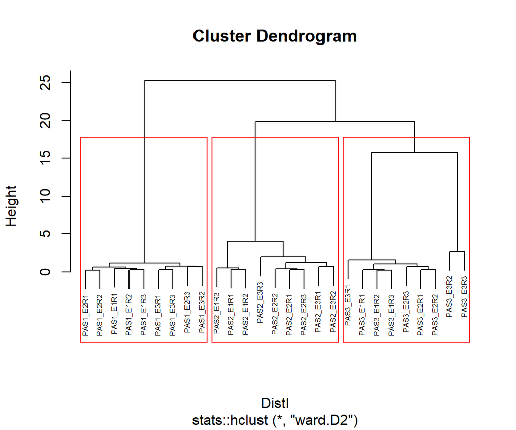

```
## [1] "CarreLatin_Manual_500P"
```

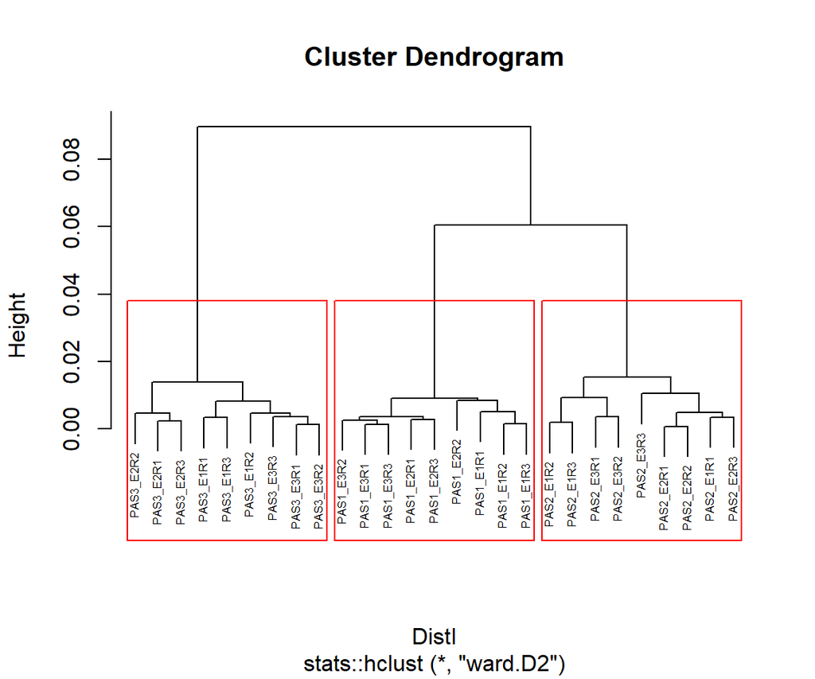

```r
pander(clustres)
```

Table continues below

|  | DunnW | DunnKM | DBW | DBKM | RandW |
| --- | --- | --- | --- | --- | --- |
| **CarreLatin_full_PEPS** | 0.5941 | 0.5941 | 0.7321 | 0.7321 | 1 |
| **CarreLatin_Manual_500P** | 1.308 | 1.308 | 0.4731 | 0.4731 | 1 |

|  | RandKM | AdjRandW | AdjRandKM |
| --- | --- | --- | --- |
| **CarreLatin_full_PEPS** | 1 | 1 | 1 |
| **CarreLatin_Manual_500P** | 1 | 1 | 1 |

Dans les deux cas, on retrouve nos trois patients, même si les sous-groupe diffèrent entre les deux analyses.

## 2.4 PLS-DA

Finalement on utilise une régréssion des moindres carrés partielle afin de comparer la classification obtenue par les deux traitements.

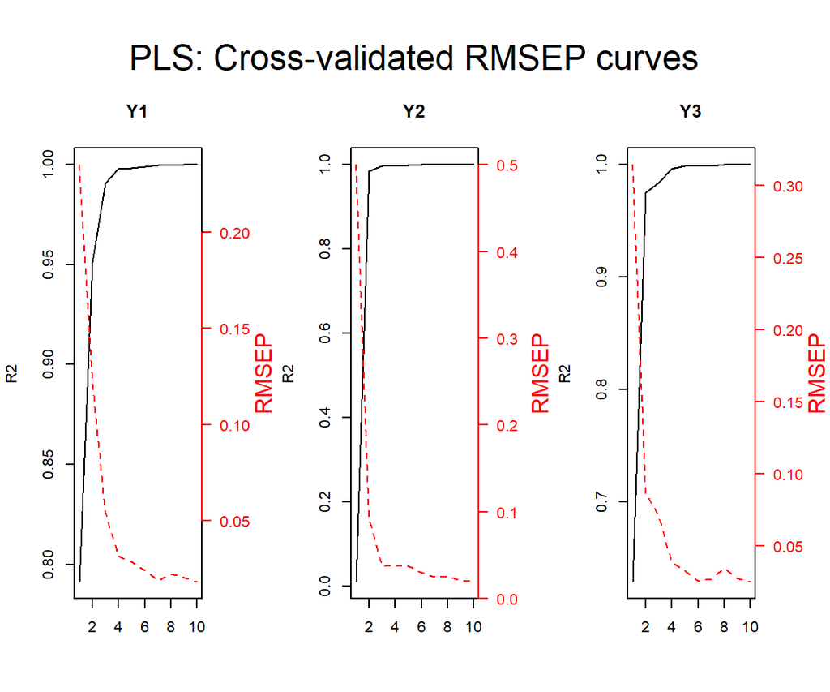

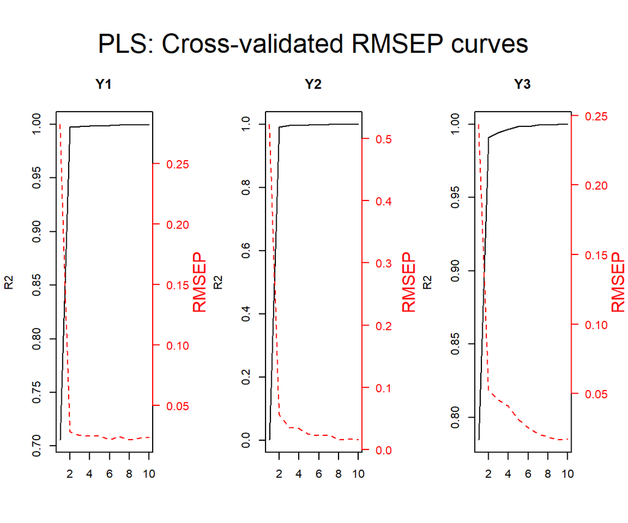

```r
nLVPLSDA = 4  # nombre du composantes du PLSDA
nrep=nlevels(as.factor(groupes)) # Nombre de rÃ©ponses
PLSDA.res=list()
perf.plsda.RMSEP=matrix(nrow=nmatrices,ncol=nrep)
dimnames(perf.plsda.RMSEP)=list(spectral_matrices_names,paste0("Y",1:nrep))
perf.plsda.R2=perf.plsda.RMSEP
perf.plsda.Q2=perf.plsda.RMSEP
for(i in 1:nmatrices)
{
# cat("PLS-DA pour ",spectral_matrices_names[i])
PLSDA.res [[i]]= PLSDA(x = spectral_matrices_list[[i]], y = groupes, nLV = nLVPLSDA, drawRMSEP = TRUE)
perf.plsda.RMSEP[i,] = PLSDA.res[[i]]$RMSEP
perf.plsda.R2[i,]=PLSDA.res[[i]]$R2
perf.plsda.Q2[i,]=PLSDA.res[[i]]$Q2
}
```

```r
pander(list(RMSEP=perf.plsda.RMSEP,R2=perf.plsda.R2,Q2=perf.plsda.Q2))
```

- **RMSEP**:

  |  | Y1 | Y2 | Y3 |
  | --- | --- | --- | --- |
  | **CarreLatin_full_PEPS** | 0.03437 | 0.03432 | 0.03924 |
  | **CarreLatin_Manual_500P** | 0.02536 | 0.03427 | 0.0405 |

- **R2**:

  |  | Y1 | Y2 | Y3 |
  | --- | --- | --- | --- |
  | **CarreLatin_full_PEPS** | 0.9976 | 0.9967 | 0.9961 |
  | **CarreLatin_Manual_500P** | 0.9984 | 0.9972 | 0.9965 |

- **Q2**:

  |  | Y1 | Y2 | Y3 |
  | --- | --- | --- | --- |
  | **CarreLatin_full_PEPS** | 0.9947 | 0.9947 | 0.9931 |
  | **CarreLatin_Manual_500P** | 0.9971 | 0.9947 | 0.9926 |

Les performances des deux jeux de données sont très proches.

### 2.4.1 Score plots de la PLS_DA

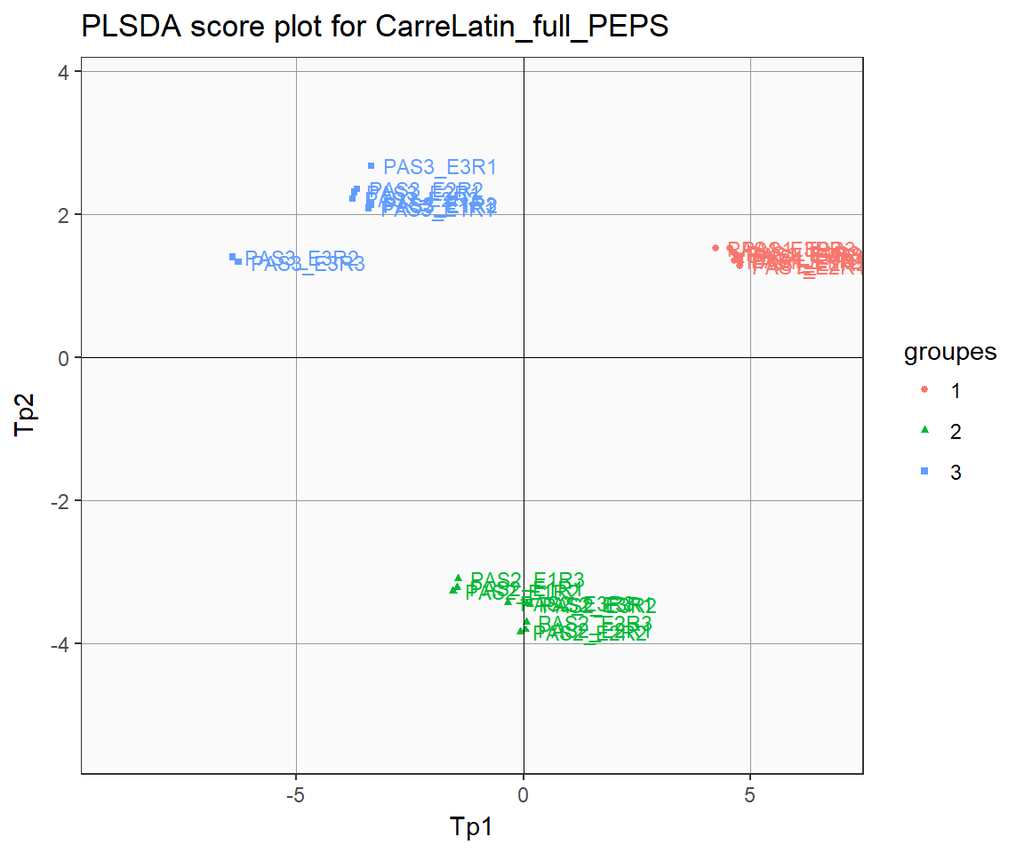

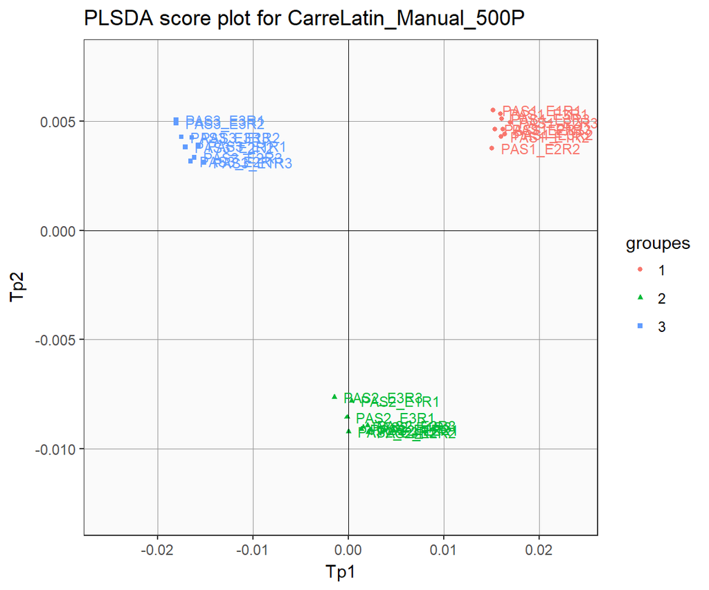

```r
PLSDA.scores= vector("list")
for(i in 1:nmatrices)
{
PLSDA.scores[[spectral_matrices_names[i]]]=DrawScores(PLSDA.res[[i]], drawNames=TRUE, type.obj = c("PLSDA"),
        createWindow=FALSE, main = paste0("PLSDA score plot for ", spectral_matrices_names[i]),pch = groupes,col = groupes, axes =c(1,2))
}
PLSDA.scores
```

On retrouve les résultats déjà constatés avec l’ACP.

### 2.4.2 Loading plots de la PLS_DA

```
## $CarreLatin_full_PEPS
## $CarreLatin_full_PEPS[[1]]
```

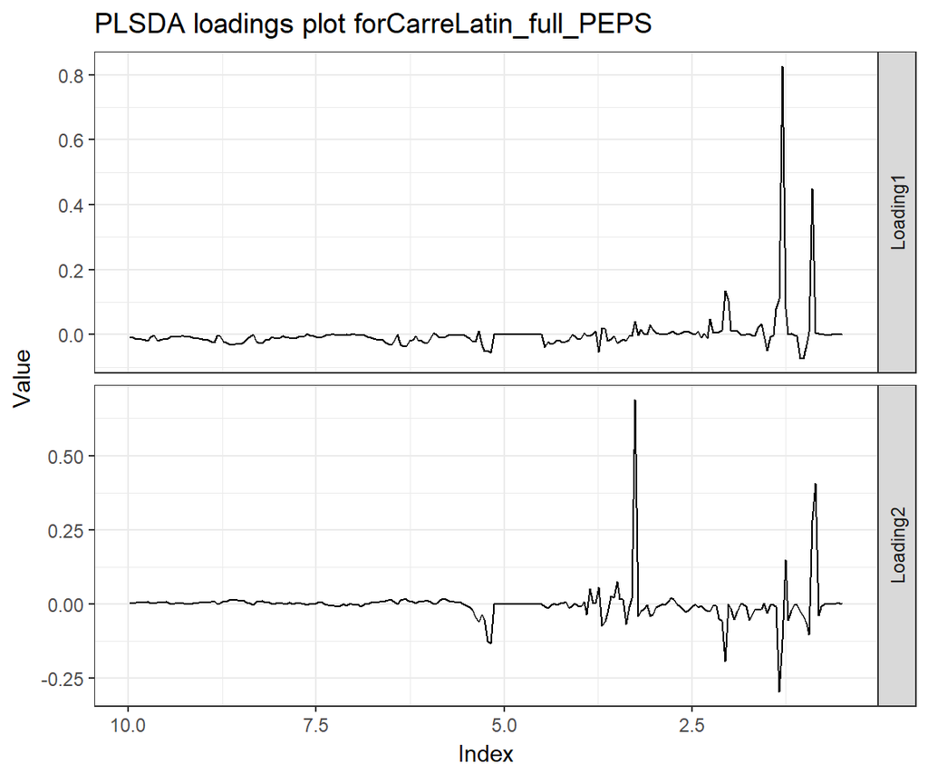

```
##
##
## $CarreLatin_Manual_500P
## $CarreLatin_Manual_500P[[1]]
```

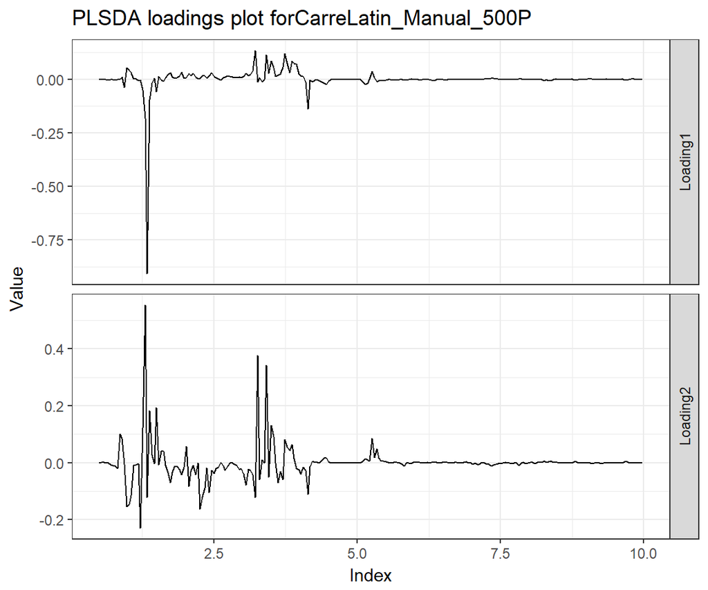

```r
PLSDA.loadings= vector("list")
for(i in 1:nmatrices)
{
PLSDA.loadings[[spectral_matrices_names[i]]]=DrawLoadings(PLSDA.res[[i]],  type.obj = "PLSDA",
        createWindow=FALSE, main = paste0("PLSDA loadings plot for", spectral_matrices_names[i]),
        axes = c(1:2),  loadingstype="l", num.stacked = 2)
}
PLSDA.loadings
```

Les graphiques de loadings expliquent les différences constatées dans les scores plots, en effet on voit par exemple que les variables qui expliquent le premier axe ne sont pas toujours les même selon le jeu de données étudié.